# Analise da criminalidade no Estado de São Paulo do ano de 2003

Ricardo Martinelli de Oliveira

November 22, 2017

# 1 Introdução

O objetivo dessa análise é trazer a partir da série histórica de 2003 sobre os dados da criminalidade do Estado de São Paulo. A partir dessa análise será feira ano a ano uma análise detalhada sobre os crimes relatados através dos Boletins de Ocorrência(BO) em posse da Secretaria de Segurança Pública(SSP)[^1] do Estado de São Paulo. Para maiores informações sobre os dados de BOs basta acessar [esse link](http://www.ssp.sp.gov.br/transparenciassp/Consulta.aspx).

## 1.1 Nomenclaturas

- **SSP**: Secretaria de Segurança Pública
- **BO**: Boletim de Ocorrência
- **RDO**: Registro Digital de Ocorrências
- **DGP**: Delegacia Geral da Polícia

# 2 Análise

No ano de 2003, a SSP liberou dados de BO dos seguintes tipos de crimes:

- Furto de Veículo
- Homicídio
- Latrocínio
- Lesão Seguida de Morte
- Roubo de Veículo

Somados os dados desses datasets temos 45723 observações, ou seja, o número de BOs registrados durante o ano de 2003 divulgados no site da SSP. O dataset possui no geral as seguintes colunas:

```
##  [1] "ANO_BO"                   "NUM_BO"
##  [3] "NUMERO_BOLETIM"           "BO_INICIADO"
##  [5] "BO_EMITIDO"               "DATAOCORRENCIA"
##  [7] "PERIDOOCORRENCIA"         "DATACOMUNICACAO"
##  [9] "DATAELABORACAO"           "BO_AUTORIA"
## [11] "FLAGRANTE"                "NUMERO_BOLETIM_PRINCIPAL"
## [13] "LOGRADOURO"               "NUMERO"
## [15] "BAIRRO"                   "CEP"
## [17] "CIDADE"                   "UF"
## [19] "LATITUDE"                 "LONGITUDE"
## [21] "DESCRICAOLOCAL"           "EXAME"
## [23] "SOLUCAO"                  "DELEGACIA_NOME"
## [25] "DELEGACIA_CIRCUNSCRICAO"  "ESPECIE"
## [27] "RUBRICA"                  "DESDOBRAMENTO"
## [29] "STATUS"                   "NOMEPESSOA"
## [31] "TIPOPESSOA"               "VITIMAFATAL"
## [33] "RG"                       "RG_UF"
## [35] "NATURALIDADE"             "NACIONALIDADE"
## [37] "SEXO"                     "DATANASCIMENTO"
## [39] "IDADE"                    "ESTADOCIVIL"
## [41] "PROFISSAO"                "GRAUINSTRUCAO"
## [43] "CORCUTIS"                 "NATUREZAVINCULADA"
## [45] "TIPOVINCULO"              "PLACA_VEICULO"
## [47] "UF_VEICULO"               "CIDADE_VEICULO"
## [49] "DESCR_COR_VEICULO"        "DESCR_MARCA_VEICULO"
## [51] "ANO_FABRICACAO"           "ANO_MODELO"
## [53] "DESCR_TIPO_VEICULO"       "ENDERECOCOMPLETO"
## [55] "COORDENADAS"              "CRIME"
```

Dentre as 56 colunas dos datasets temos dados detalhados sobre cada BO, porém cada crime tem suas particularidades. Ex.: Um BO de furto de veículo não terá dados sobre pessoas uma vez que esses dados são para uso de descrição das vítimas[^2] dos crimes onde houve uma vítima fatal. Outro ponto a ser considerado é a ocasião de aparentemente haver duplicidade de registro de BOs. Isso se deve ao fato de que alguns BOs recebem um complemento (os chamados BOs complementares) que recebem um novo número, e a partir desse número é anexado o número anterior(o chamado BO principal) e compõe o BO como um todo.

O gráfico abaixo mostra a quantidade de BOs por tipo de crime. Notem que o maior número de BOs relatados são de roubo e furto de veículo. Isso se deve pela facilidade em se reportar BOs para assim entrar com sinistros em seguradoras (lembrando que tais dados vêm do registro digital de ocorrências) e por isso facilitou muito acionar as seguradoras no caso de furto ou roubo de um veículo.

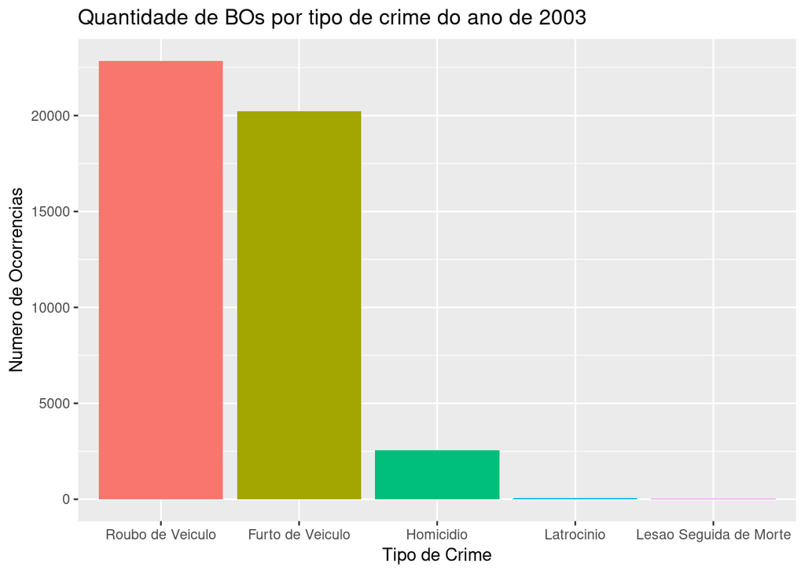

Já o gráfico abaixo mostra o número do ranking das 20 cidades com maiores números de BOs registrados no ano. É importante notar que na ordem das cidades com maior número de ocorrências encontram-se as cidades localizadas na região metropolitana de São Paulo.

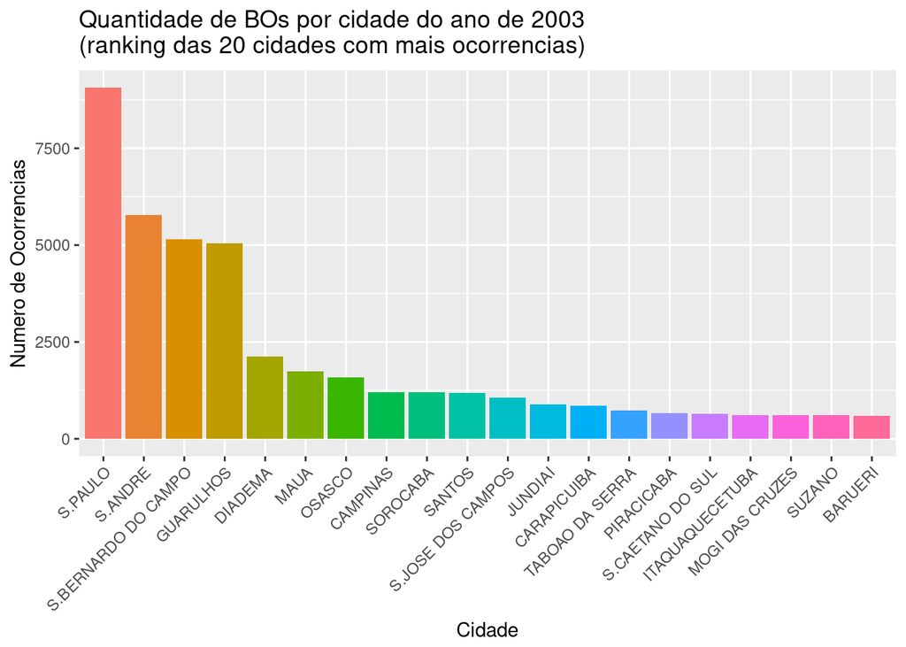

A cidade de São Paulo possuía 5.649.318 de veículos registrados em 2003, de acordo com dados do Detran de SP. Com base nisso, justifica-se o número de ocorrências ser alto na cidade de São Paulo nesse ano. Para maiores detalhes, veremos o gráfico abaixo de número de BOs pelo mesmo ranking das 20 cidades, dessa vez classificando-os por tipo de crime.

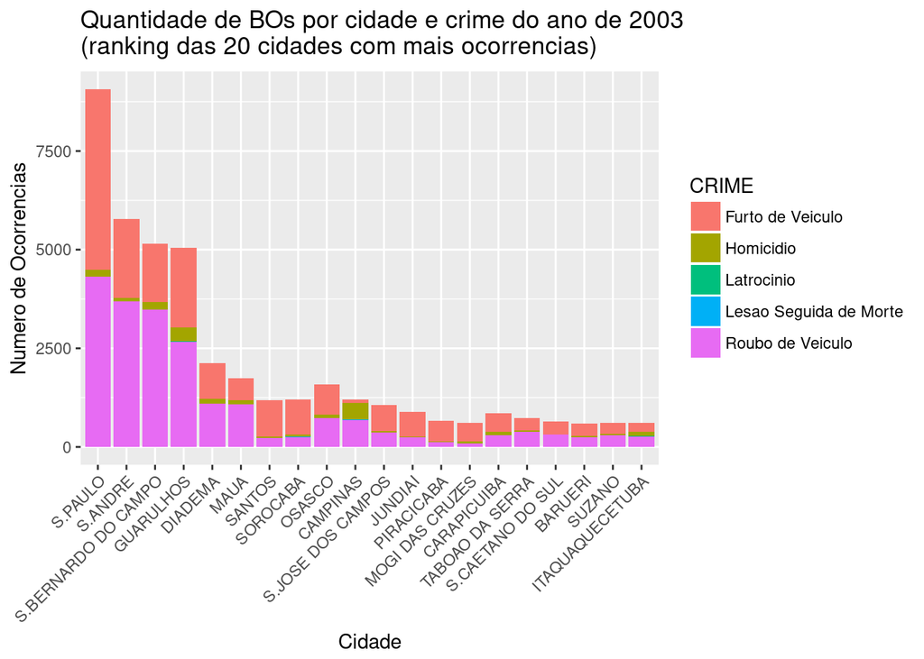

# 3 Problemas

No pouco de análise feita nesse dataset, analisarei nas próximas seções os maiores problemas enfrentados por esses dados.

## 3.1 Crimes com datasets muito pequenos

Infelizmente, o dataset contém um número muito baixo de dados, inviabilizando uma análise mais detalhada da criminalidade do ano de 2003. De acordo com o dataset gerado, temos os seguintes números:

- **Furto de Veículo**: 20228
- **Homicídio**: 2551
- **Latrocínio**: 65
- **Lesão Seguida de Morte**: 29
- **Roubo de Veículo**: 22850

## 3.2 Muitas variáveis com valores inexistentes

Os dados possuem diversos valores inexistentes, e alguns deles possuem ausência de dados georreferenciados. Isso torna o trabalho complexo para se criar um mapa da criminalidade que possa ser colocado num mapa. Veremos os dados de números inexistentes para cada crime:

- **Furto de Veículo**

```
##                   ANO_BO                   NUM_BO           NUMERO_BOLETIM
##                        0                        0                        0
##              BO_INICIADO               BO_EMITIDO           DATAOCORRENCIA
##                        0                        0                        0
##         PERIDOOCORRENCIA          DATACOMUNICACAO           DATAELABORACAO
##                        0                        0                        0
##               BO_AUTORIA                FLAGRANTE NUMERO_BOLETIM_PRINCIPAL
##                        0                        0                        0
##               LOGRADOURO                   NUMERO                   BAIRRO
##                        0                        0                        0
##                      CEP                   CIDADE                       UF
##                    19089                        0                        0
##                 LATITUDE                LONGITUDE           DESCRICAOLOCAL
##                    20228                    20228                        0
##                    EXAME                  SOLUCAO           DELEGACIA_NOME
##                        0                        0                        0
##  DELEGACIA_CIRCUNSCRICAO                  ESPECIE                  RUBRICA
##                        0                        0                        0
##            DESDOBRAMENTO                   STATUS               NOMEPESSOA
##                     1980                        0                    20228
##               TIPOPESSOA              VITIMAFATAL                       RG
##                    20228                    20228                    20228
##                    RG_UF             NATURALIDADE            NACIONALIDADE
##                    20228                    20228                    20228
##                     SEXO           DATANASCIMENTO                    IDADE
##                    20228                    20228                    20228
##              ESTADOCIVIL                PROFISSAO            GRAUINSTRUCAO
##                    20228                    20228                    20228
##                 CORCUTIS        NATUREZAVINCULADA              TIPOVINCULO
##                    20228                    20228                    20228
##            PLACA_VEICULO               UF_VEICULO           CIDADE_VEICULO
##                    20228                    20228                    20228
##        DESCR_COR_VEICULO      DESCR_MARCA_VEICULO           ANO_FABRICACAO
##                    20228                    20228                    18743
##               ANO_MODELO       DESCR_TIPO_VEICULO         ENDERECOCOMPLETO
##                    18743                    20228                        0
##              COORDENADAS                    CRIME
##                        0                        0
```

- **Homicídio**

```
##                   ANO_BO                   NUM_BO           NUMERO_BOLETIM
##                        0                        0                        0
##              BO_INICIADO               BO_EMITIDO           DATAOCORRENCIA
##                        0                        0                        0
##         PERIDOOCORRENCIA          DATACOMUNICACAO           DATAELABORACAO
##                        0                        0                        0
##               BO_AUTORIA                FLAGRANTE NUMERO_BOLETIM_PRINCIPAL
##                        0                        0                        0
##               LOGRADOURO                   NUMERO                   BAIRRO
##                        0                        0                        0
##                      CEP                   CIDADE                       UF
##                     2414                        0                        0
##                 LATITUDE                LONGITUDE           DESCRICAOLOCAL
##                     2551                     2551                        0
##                    EXAME                  SOLUCAO           DELEGACIA_NOME
##                        0                        0                        0
##  DELEGACIA_CIRCUNSCRICAO                  ESPECIE                  RUBRICA
##                        0                        0                        0
##            DESDOBRAMENTO                   STATUS               NOMEPESSOA
##                      168                        0                     2551
##               TIPOPESSOA              VITIMAFATAL                       RG
##                     2551                     2551                     2551
##                    RG_UF             NATURALIDADE            NACIONALIDADE
##                     2551                     2551                     2551
##                     SEXO           DATANASCIMENTO                    IDADE
##                     2551                     2551                     2551
##              ESTADOCIVIL                PROFISSAO            GRAUINSTRUCAO
##                     2551                     2551                     2551
##                 CORCUTIS        NATUREZAVINCULADA              TIPOVINCULO
##                     2551                     2551                     2551
##            PLACA_VEICULO               UF_VEICULO           CIDADE_VEICULO
##                     2551                     2551                     2551
##        DESCR_COR_VEICULO      DESCR_MARCA_VEICULO           ANO_FABRICACAO
##                     2551                     2551                     2551
##               ANO_MODELO       DESCR_TIPO_VEICULO         ENDERECOCOMPLETO
##                     2551                     2551                        0
##              COORDENADAS                    CRIME
##                        0                        0
```

- **Latrocínio**

```
##                   ANO_BO                   NUM_BO           NUMERO_BOLETIM
##                        0                        0                        0
##              BO_INICIADO               BO_EMITIDO           DATAOCORRENCIA
##                        0                        0                        0
##         PERIDOOCORRENCIA          DATACOMUNICACAO           DATAELABORACAO
##                        0                        0                        0
##               BO_AUTORIA                FLAGRANTE NUMERO_BOLETIM_PRINCIPAL
##                        0                        0                        7
##               LOGRADOURO                   NUMERO                   BAIRRO
##                        0                        0                        0
##                      CEP                   CIDADE                       UF
##                       63                        0                        0
##                 LATITUDE                LONGITUDE           DESCRICAOLOCAL
##                       65                       65                        0
##                    EXAME                  SOLUCAO           DELEGACIA_NOME
##                        0                        0                        0
##  DELEGACIA_CIRCUNSCRICAO                  ESPECIE                  RUBRICA
##                        0                        0                        0
##            DESDOBRAMENTO                   STATUS               NOMEPESSOA
##                        0                        0                       65
##               TIPOPESSOA              VITIMAFATAL                       RG
##                       65                       65                       65
##                    RG_UF             NATURALIDADE            NACIONALIDADE
##                       65                       65                       65
##                     SEXO           DATANASCIMENTO                    IDADE
##                       65                       65                       65
##              ESTADOCIVIL                PROFISSAO            GRAUINSTRUCAO
##                       65                       65                       65
##                 CORCUTIS        NATUREZAVINCULADA              TIPOVINCULO
##                       65                       65                       65
##            PLACA_VEICULO               UF_VEICULO           CIDADE_VEICULO
##                       65                       65                       65
##        DESCR_COR_VEICULO      DESCR_MARCA_VEICULO           ANO_FABRICACAO
##                       65                       65                       10
##               ANO_MODELO       DESCR_TIPO_VEICULO         ENDERECOCOMPLETO
##                       10                       65                        0
##              COORDENADAS                    CRIME
##                        0                        0
```

- **Lesão Seguida de Morte**

```
##                   ANO_BO                   NUM_BO           NUMERO_BOLETIM
##                        0                        0                        0
##              BO_INICIADO               BO_EMITIDO           DATAOCORRENCIA
##                        0                        0                        0
##         PERIDOOCORRENCIA          DATACOMUNICACAO           DATAELABORACAO
##                        0                        0                        0
##               BO_AUTORIA                FLAGRANTE NUMERO_BOLETIM_PRINCIPAL
##                        0                        0                       15
##               LOGRADOURO                   NUMERO                   BAIRRO
##                        0                        0                        0
##                      CEP                   CIDADE                       UF
##                       23                        0                        0
##                 LATITUDE                LONGITUDE           DESCRICAOLOCAL
##                        2                        2                        0
##                    EXAME                  SOLUCAO           DELEGACIA_NOME
##                        0                        0                        0
##  DELEGACIA_CIRCUNSCRICAO                  ESPECIE                  RUBRICA
##                        0                        0                        0
##            DESDOBRAMENTO                   STATUS               NOMEPESSOA
##                       29                        0                       29
##               TIPOPESSOA              VITIMAFATAL                       RG
##                       29                       29                       29
##                    RG_UF             NATURALIDADE            NACIONALIDADE
##                       29                       29                       29
##                     SEXO           DATANASCIMENTO                    IDADE
##                       29                       29                       29
##              ESTADOCIVIL                PROFISSAO            GRAUINSTRUCAO
##                       29                       29                       29
##                 CORCUTIS        NATUREZAVINCULADA              TIPOVINCULO
##                       29                       29                       29
##            PLACA_VEICULO               UF_VEICULO           CIDADE_VEICULO
##                       29                       29                       29
##        DESCR_COR_VEICULO      DESCR_MARCA_VEICULO           ANO_FABRICACAO
##                       29                       29                        0
##               ANO_MODELO       DESCR_TIPO_VEICULO         ENDERECOCOMPLETO
##                        0                       29                        0
##              COORDENADAS                    CRIME
##                        0                        0
```

- **Roubo de Veículo**

```
##                   ANO_BO                   NUM_BO           NUMERO_BOLETIM
##                        0                        0                        0
##              BO_INICIADO               BO_EMITIDO           DATAOCORRENCIA
##                        0                        0                        0
##         PERIDOOCORRENCIA          DATACOMUNICACAO           DATAELABORACAO
##                        0                        0                        0
##               BO_AUTORIA                FLAGRANTE NUMERO_BOLETIM_PRINCIPAL
##                        0                        0                        0
##               LOGRADOURO                   NUMERO                   BAIRRO
##                        0                        0                        0
##                      CEP                   CIDADE                       UF
##                    21782                        0                        0
##                 LATITUDE                LONGITUDE           DESCRICAOLOCAL
##                    22850                    22850                        0
##                    EXAME                  SOLUCAO           DELEGACIA_NOME
##                        0                        0                        0
##  DELEGACIA_CIRCUNSCRICAO                  ESPECIE                  RUBRICA
##                        0                        0                        0
##            DESDOBRAMENTO                   STATUS               NOMEPESSOA
##                        0                        0                    22850
##               TIPOPESSOA              VITIMAFATAL                       RG
##                    22850                    22850                    22850
##                    RG_UF             NATURALIDADE            NACIONALIDADE
##                    22850                    22850                    22850
##                     SEXO           DATANASCIMENTO                    IDADE
##                    22850                    22850                    22850
##              ESTADOCIVIL                PROFISSAO            GRAUINSTRUCAO
##                    22850                    22850                    22850
##                 CORCUTIS        NATUREZAVINCULADA              TIPOVINCULO
##                    22850                    22850                    22850
##            PLACA_VEICULO               UF_VEICULO           CIDADE_VEICULO
##                    22850                    22850                    22850
##        DESCR_COR_VEICULO      DESCR_MARCA_VEICULO           ANO_FABRICACAO
##                    22850                    22850                    15452
##               ANO_MODELO       DESCR_TIPO_VEICULO         ENDERECOCOMPLETO
##                    15452                    22850                        0
##              COORDENADAS                    CRIME
##                        0                        0
```

Para tanto, o trabalho feito para criar tais dados georreferenciados foi utilizar da API do Google Maps para conseguir trazer esses dados. Como o dataset é pequeno, pode-se coletar esses dados pela API, mas pelo fato de a API ter uma limitação para uma busca gratuita isso pode se tornar uma limitação e com isso seja necessário pagar para conseguir trazer esses dados num dataset muito maior. Esse até o momento é a maior limitação do dataset para qualquer análise que possa ser feita, e para os próximos anos procurarei uma forma melhor de conseguir os dados.

# 4 Conclusão

Os dados deste dataset ficarão disponibilizados de forma georreferenciada no link [Mapas](https://rimolive.github.io/mapa-crime-sp/).

[^1]: A fonte dos dados de transparência é do Sistema de Registro Digital de ocorrências (RDO) e portanto nem todos os BOs estão nessa análise.
[^2]: Para garantir a privacidade das famílias envolvidas, nomes e outros dados pessoais não serão mencionados.
[^3]: http://www.ssp.sp.gov.br/Estatistica/Pesquisa.aspx
[^4]: https://www.imprensaoficial.com.br/DO/BuscaDO2001Documento_11_4.aspx?link=/2000/executivo%2520secao%2520i/fevereiro/08/pag_0004_BJ38O6LIT2E5Ce7C7APATTUKPJU.pdf&pagina=4&data=08/02/2000&caderno=Executivo%20I&paginaordenacao=100004